# 文思泉涌：如何克服学术写作拖延症

How to Write a Lot: A Practical Guide to Productive Academic Writing

保罗・J.席尔瓦 (著) 胡颖 (译)

无论是学生还是教授，都需要写作。然而，写作让许多人感到头痛。

拖延症，是学术圈的流行病，是久治不愈的顽疾……心理学家保罗・J.席尔瓦的这本小册子，实用、励志而轻松；它告诉你写作不需要太多的天赋或特殊才能，

而需要策略、方法和行动。

遵循此书中的建议，你不用熬夜，也能成为文思泉涌的学术牛人，既不耽误享受生活，又能获得高效率写作带来的成就感，

走向学术生涯的高峰。

**成为一个多产的学术写作者，靠的是后天习得的技能，而不是先天的禀赋，所以，写作这件事是可以学的。** 这本小册子将告诉你

- 怎样把写作变成一件稀松平常的事。
- 怎样才能在正常的教学周内腾出时间写作，怎样才能在写作时放松心情，以及怎样才能更高效地写作。

如果你有积压如山的原始数据，如果你总是担心找不到时间写东西，或者你想让写作变得容易些，那么这本小册子或许能够帮到你。

斯蒂芬•金(StephenKing,2000:155)：

> "一间作家的书房，真正需要的，仅仅是一扇你想要关上的门。”

## 第一章 导言

我会把注意力集中在你“外在”的写作者角色上。

- 高效写作的要求其实很简单：制订时间表，设定目标，时时跟踪你的工作，奖励自己和养成良好的习惯。
- 多产的写作者并没有什么特殊技能，他们只是花了更多的时间在写作上，同时，他们的效率更高而已(Keyes,2003)。
- 改变你的写作习惯并不会使写作过程变得更有趣，但是会使它变得容易和轻松。

### 一、写作的确是件难事

做研究充满欢喜。但是，写作是辛苦的、复杂的和无趣的。威廉•津泽(WilliamZinsser,2001:12)说：“如果你觉得写作很难，那是因为写作的确很难。”

- 正是因为收集数据比写作来得容易，许多教授都有堆积如山的研究数据。
- 教授们热切盼望着长周末、春假、法定假日和暑假。
- 写作时间总是被其他更为重要的事情侵占，比如朋友聚会、家庭聚餐、炖锅扁豆汤或是给自家的狗织一顶圣诞帽。

这年头，要想在科研领域混口饭吃，真的不容易！

### 二、我们现在学习写作的方式

- 写作是一项技能，而不是什么天赋或特殊才能。
- 像所有的高级技能一样，写作技能必须通过系统的指导和实践来培养。
- 人们必须学习相关的规则和策略，并努力实践(Ericsson,Krampe&Tesch-Romcr,1993)。

心理学家早已发现，有意识的练习有助于技能培养，但是这一理论似乎还没被用于培养写作技能。

- 最常见的模式是指望学生们能够通过向他们的导师学习来掌握写作的技能。问题是，很多导师自己就在“水深火热”中挣扎——他们常常抱怨根本没有时间写作，常常眼巴巴地等待春假或是暑假的来临。这简直就是盲人骑瞎马。

### 三、本书的解决之道

《文思泉涌——如何克服学术写作拖延症》视写作为一系列具体的行为，就像：（1）首先在椅子/板凳/高脚凳/长软椅/马桶/草地上坐下来；（2）然后敲打键盘，写出一段文字。你绝对能够通过简单的办法来培养这些行为。让别人尽情拖延、做白日梦和抱怨去吧,你所要做的就是：坐下来，写。

当你阅读本书时，你要记住，写作不是比赛或者游戏。你想写多少就写多少，长短无所谓。千万不要觉得你有责任写更多，也不要为了发表而发表，写一大堆毫无意义的东西。不要误以为那些发表了大量文章的心理学家就有更多的研究成果。

### 四、各章预览

- 第二章中，我们彻底检查了人们为写不出东西而找的拙劣借口。我们逐一分析这些借口，发现它们对于写作的效率毫无影响。这章将介绍如何用制订写作计划的方式来分配写作任务。
- 第三章介绍了激励你执行写作计划的各种办法。你将学到如何制订好的目标，通过确立优先性原则来同时处理多项任务，以及如何管理你的写作进程。为了帮助培养你的新习惯，你可以和朋友一起建立写作小组。
- 第四章是关于如何组建既有趣又有益的“失写互助组”(agraphiagroup)--种有助于培养良好写作习惯的互助小组。
- 第五章教你怎么写得更好。写得好的论文或是开题报告总能在众多平庸之作中脱颖而出，所以你应该努力写得更好。
- 第六章剖析了实用的心理学论文写作技巧。我们可能并不喜欢阅读论文，但是我们必须写作论文。多产的写作者告诉过我他们是怎么写论文的，主流期刊的编辑告诉过我他们希望看到怎样的论文。第六章探讨了关于论文发表的几个入门级问题，例如如何给编辑写投稿信，如何与别人合作写作。
- 第七章讲述了怎么写学术著作。心理学界为有抱负的学者们提供的资源实在有限，基于此，我就如何写学术著作及如何与出版商合作提出了一些个人见解。
- 第八章对全书作了总结，还写了很多鼓励的话。

## 第二章 妨碍写作的借口都“貌似有理”

写作是一项严峻的挑战，就好像修理污水管或是经营一家殡仪馆。

- 每次我和教授或是研究生聊起写作这桩事，他们总是提到很多阻碍因素。
  - 他们相信，如果不是这样或那样的因素妨碍了他们，他们本来能够写得更多。
- 我把这些借口称为“貌似有理”的借口。乍一看，这些妨碍写作的借口挺像模像样的，但是只要稍加深究，就会发现它们根本站不住脚。
- 本章将列举几个最为常见的妨碍写作的借口，并教大家如何用最简单的方法来克服它们。

### 一、借口一

“我找不到时间写作”，也可以称为“如果我有更多整块的时间，我就能写得更多了”。为什么这个借口是假的？

- 关键问题就在“找”字上。你需要“找时间教书”吗？
- 如果你认为写作时间藏匿在你每周计划的某个角落，你就永远不会写得更多。
- 非等到整块的时间(春假或是暑假)才能写作的话，你不会写得更多。
- “找时间”对于写作来说是毁灭性的。以后再也不要这么说了。

相反，你不应该“找时间”，而是“安排时间”来写作。高效的写作者都会**制订一个时间表并严格遵守** 。就这么简单。现在，花几分钟想一下你想要的写作时间表。好好想想你的一周安排：

- 是否每周总有那么一些相对空闲的时间？如果你周二和周四有课，那么周一和周三的早上可能是最好的写作时间。
- 如果你觉得下午或是晚上精神更好，那么就安排在晚些时候。
- 每个人根据自己的其他安排，会有不同的黄金“写作时间。
- 关键在于规律性，而不在于天数或是小时数。
- 开始的时候，你可以每周安排四个小时左右。等看到你所写的文章字数突飞猛进时，你可以再适当延长写作时间。

你每周是花一天还是五天来写作并不重要——**只要你腾出一段有规律的时间来，把它标在你的周计划表上，然后在这段时间坚持写作**。

每次讨论到写作安排时，人们总是问我：那么你的安排呢？

- 我每周一到周五上午八点到十点用来写作。
- 我起床，煮咖啡，然后坐在我的办公桌前。
- 为了避免干扰，我写作前不查邮件，不洗澡也不换衣服。
- 我起床，然后写作。开始和结束的时间可能会前后调整，不过我**每个工作日写两个小时**。
- 我不是一个喜欢早起的人，不过早上写作有很多优势，我能够在被处理邮件、学生约谈和与同事会面等事务淹没之前，抓紧宝贵时间写点东西。

大多数人都有一个既浪费时间又毫无成效的坏习惯，被称作“突击写作”(binge writing)(Kellogg,1994)。

- 一方面，想写，拖延，为拖延感到万分内疚和焦躁；另一方方面，“突击写作者”(bingewriter)最终选择某个周六什么也不做，只写东西。这样他们的负疚感得以缓解，整个“突击写作”的周期又开始循环。
- “突击写作者"花在为没有写作而感到内疚和不安上的时间，要远远超过制订计划的人花在写作上的时间。
- 当你执行计划时，你就没有时间担心、抱怨、幻想。
- 你在固定的时间写作，然后彻底忘了它。我们有很多比写作更值得关注的事情。
- 我从不担心我要找时间写这本书：我知道我会在明天早上八点钟继续。

“突击写作者”常常自我辩护：此乃天性使然，“我不是那种喜欢制订计划并能严格执行的人”。

- 这根本就是废话。人们拿天性来说事儿，是因为他们不想改变(Jcllison,1993)。
- 那些宣称自己不是“计划达人”的人在其他方面却成了计划专家：
  - 他们总是在固定的时间教书，在固定的时间上床，在固定的时间看自己喜欢的电视节目等。
  - 却无论刮风下雨都能够坚持在固定时间出门慢跑。

千万不要还没有开始就选择放弃一制订计划是高效写作的唯一秘诀。

你必须坚决地捍卫你的写作时间。记住，你要安排时间写作，而不是找时间写作。你自己决定了这段时间是用来写作的。在这段时间内，你不能与同事、学生或是导师见面与约谈；也不能批改作业或者备课；更不能查阅电子邮件、看报纸或是查看天气预报。关掉你的网络和电话，关上门。（我以前会在办公室的门上挂一个“请勿打扰”的牌子，但可恶的是，这块牌子常被人误解为“他关上了门，但是他想让我知道他在办公室，所以我应该敲门而入”。）

我得提醒你们，其他人未必会理解你对写作时间的忠诚。人们会希望在这段时间和你开个会，他们并非存心捣乱，只是无法理解你为什么没有时间。他们会怨你不知变通，认为你顽固不化，甚至揣测是不是有其他什么不便道明的原因使你不愿见他们。对我来说，最常见的问题是研究生们希望我能够早上九点见他们一这个时间对他们来说最方便，但是不巧，这正好在我的写作时间内。同样的，有时候我也不得不在写作时间里参加一些会议，因为这是唯一一个对所有与会者来说都方便的时间。

怎样应对这些无心打扰到你的人呢？对他们说“不”！你有两个很好的理由说“不'。

- 首先，只有“失败的写作者”才会把你的拒绝当作是对他的挑战。
  - 我遇到的所有认真的写作者都非常尊重我对写作时间的坚持。他们也许会有一点不高兴，因为我无法在他们希望的时间安排会面，但是他们都会表示理解，因为制订计划是写作的唯一出路（这些人也会在他们的写作时间里拒绝我的会面要求）。为此而恼怒和满腹牢骚的人都不是好的写作者，所以别受他们拖累。
- 其次，人们不会想要占用你的上课时间、你的家庭聚会时间或是你的睡觉时间，却想要占用你的写作时间，因为他们认为你的写作时间无关紧要。
  - 作为一个学者，你是职业的写作者，就像你是一名职业的教师一样。
  - 把你的写作时间当成你的上课时间，对那些无心打扰的人说“不”，并解释为什么你不能打破你的写作计划。如果你不喜欢说“不”，那就撒谎。如果你也不喜欢撒谎，那就归咎于一个“常见又固定的职责”或是一个“世俗的拖累”。

在既定的写作时间里奋笔疾书，但是也不要教条化地囿于写作时间。

- 如果你在写作时间结束后仍然文思泉涌或者在其他时间里坚持写作，岂不是更好？我把这称为“意外之作”。
- 一旦你养成了习惯，坐下来写东西就会变得容易了。
- **警惕**：不能用“意外写作”来替代正常的写作时间。

不管你在放春假的时候写了多少——你都应该遵守你的写作计划，严格执行。如果你发现自己胡说一一“我周末已经写得够多了，周一我就轻松一下吧”，那这本书能够帮到你：合上它，用你非惯用的那只手的拇指和食指夹住它，在自己面前狂甩五分钟，以便提醒你怎样才是正确的做法。

或许你对“计划写作”是否有效还有保留意见。“这真的就是秘诀吗？”你也许会问，“难道就没有其他的法子能够多写点？”没有了一做好计划并严格执行是唯一的办法。

职业写作者拉夫•凯斯(RalphKeyes,2003：49)发现，“使一位写作者得以高产的秘诀就是坐在书桌前日复一日地写作”。

如果你每周安排四个小时写作，你会对你能够完成的字数感到惊讶，确切地说是震惊,惊得哑口无言，呆若木鸡。

- 你会发现自己完成了之前无法想象的事，例如提早完成了开题报告。
- 你会收到改稿通知，并在一周内完成。
- 你不敢再和系里的同事交流对象牙塔之旅学术写作指导丛书写作的恐惧，因为你害怕他们会说“你已经不再是我们的战友了”，而且他们的话千真万确。

### 二、借口二

“我需要先作一些数据分析”，或者“我要先看几篇文章”。这个借口最为阴险，危害也最大。

- 你也许会说，“我总不能既不看参考文献又不作数据分析，就直接写文章吧”。
- 但是他们写得不多，也从不作所谓的数据分析。“突击写作者”往往也是“突击阅读者”和“突击数据分析员”，阻碍他们写作的坏习惯同样会妨碍他们做其他与写作相关的准备工作(Kellogg,1994)—阅读、列提纲、提炼观点、分析数据，等等。
- 像其他所有“貌似有理”的借口一样，这个借口也经不起深究。

要破解它很容易：在你安排的写作时间内，做一切你需要做的事情。

- 要做一些数据分析吗？在你的计划时间里做。
- 要看一些参考文献吗？在你的计划时间里做。
- 要校验清样吗？也在你的计划时间里完成。
- 要读一本如何写作的书呢？你知道应该什么时候读。

> 写作的含义远不只是坐在电脑前打字，任何与完成写作任务相关的活动均可称为写作。
- 例如，为了完成一篇论文，我常常会连续花几段写作时间来作数据分析。
- 有时候我会花上一整段写作时间来做一些鸡毛蒜皮的事，比如研究某一杂志的投稿要求、画图表或校样稿。

这也是为什么只有制订计划才能够保障写得更多的又一原因。专业的写作包含很多部分：广泛的文献阅读、仔细的分析、文字严谨的研究方法陈述。

- 我们无法“找时间”来完成所有相关文献的检索与阅读，就如同我们无法“找时间”写下阅读这些文章的笔记。
- 所以安排好你的写作时间来完成这些工作吧。这样你就不会为找不到时间来读文献和作分析而感到惶恐了，因为你知道什么时候你会完成它们。

### 三、借口三

“我需要一台新电脑才能更好地写作”（同理，这里的“电脑”可以替换为“新的激光打印机”“新椅子”“新书桌”)。在所有的借口中，这条是最让人抓狂的，其实真的只能勉强算是一个“借口”。

- 当我还在读研究生时，我刚开始严肃地写作，我从一个同学的男朋友那里买了一台很旧的电脑。这台电脑即使在1996年也可以算是一件古董：没有鼠标，没有Windows,只有一个键盘和DOS系统下的WordPerfect软件。这台电脑寿终正寝以后，我的一些文件也因为无法复制而随之陪葬。
- 我又买了一台手提电脑，常常席地埋头苦写。
- 我现在正在用2001年购买的一台速度奇慢、老得掉牙的东芝笔记本电脑写这本书——在如今电脑更新换代如此迅速的时代，我的这台笔记本电脑老得都可以去领养老金了。

大概有八年的时间，我都坐在一把折叠椅上辛勤笔耕。这把折叠椅退休以后，替代它的是一把稍微时髦，但是同样坚硬的老式埃姆斯椅。它是一把再简单不过的椅子：没有装饰和靠垫，也不能调节高度和角度。

- 只有一张大而简单的书桌（没有抽屉,没有键盘架，没有豪华的文件收纳体系，等等）、一台激光打印机和一个咖啡杯垫。
- 在我买下这张“蓝点"书桌以前，我用的是一张10美元的胶合板折叠书桌，为了显示我的品位，上面铺了一块4美元的桌布。
- 我就坐在那把折叠椅上，在那张折叠书桌旁，写完了我那本关于兴趣的专著的大部分内容（Silvia,2006）和近20篇学术论文。

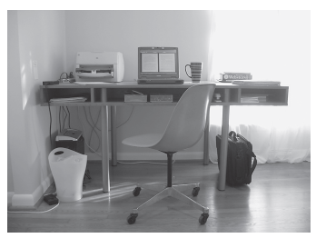

图2.1 我写作本书的地方

低效的写作者总喜欢悲悲切切地抱怨没有属于自己的哪怕一小块空间用来写作。我对这个老掉牙的借口不屑一顾。

- 我从来没有专属的家庭办公室或是私人写作空间。在狭小的公寓或是房子里，我在客厅、卧室、客卧、主卧甚至浴室里写作，我只需要一张小桌子。我在家里的客卧里完成了这本书的写作。
- 即使现在，我已经写了那么多书和论文，也买了自己的房子，我在家还是没有独立的书房来写作。我也不需要——总有一间浴室是空着的。

当人们抱怨他们家里没有高速互联网时，我真心祝贺他们有这样正确的判断。

- 如果你们仔细看图2.1,就会发现我的电脑上根本没接网线。这玩意儿只会让我分散注意力。
- 写作时间就是用来写作的，不是用来查邮件、看新闻，或是浏览最新期刊的。
- 有时候我会觉得下载一些文章可能对写作有点帮助，不过我可以在办公室里下载。最好的自控就是让客观环境不需要自控。

威廉,萨拉扬(WilliamSaroyan,1952：42)这样写道，“写作，你只需要一张纸和一支笔。”

设备永远不能帮你写作；只有制订写作计划并努力执行才能帮助你成为一名高效的写作者。

### 四、借口四

“我只是在等待对的时机”，或者“我在灵感来临的时候才能写出好的文章”。这最后一个借口是最可笑和最无厘头的。

- “好的作品都是在我有灵感的时候一气呵成的,”他们说，“在我没有心情的时候逼着我写也无济于事。我必须感到我想写了才行。”毫无建树的写作者这样说真是可笑。
- 这就好像烟鬼们总是辩解吸烟能够使他们感到放松，而实际上吸入尼古丁压根儿就只会导致精神紧张(Parrott,1999)。
- 当那些备受折磨的人为不制订计划而辩解时，他们是在支持使他们深受折磨的原因本身。

如果你相信你应该只在有灵感的时候写文章，那就请你问自己几个简单的问题

- 这种策略效果如何？
- 你对自己文章的数量感到满意吗？
- 你是否常常为找时间写作或是为仅仅完成了一半的论文而感到紧张？
- 你是否牺牲了晚上或是周末的时间用来写作？

要驳倒这个借口也不难：研究表明等待灵感是徒劳的。博伊斯（Boice,1990：79-81）为那些等待灵感的突击写作者做了一个意义深远的研究。他召集了一批为写作而头痛的大学教授，随机地给他们分配了不同的写作策略。

- 第一组（限制写作组）的教授们被禁止在任何非紧急情况下写作；
- 第二组（顺其自然组）的教授们有50段写作时间，但是仅在他们感到有灵感的时候写；
- 第三组（附加干预组）的教授们有50段写作时间，并且在这些时间内必须写作（如果他们没写，就得向一个他们不喜欢的组织交罚款）。

- 首先，附加干预组的产量最高：他们的产量是顺其自然组的3.5倍，是限制写作组的16倍。
  - 那些只在有灵感的时候写作的人比那些被告知没事别写的人多写了一点点——灵感的作用实在是被高估了。
- 其次,那些被逼着写作的人提出了更多创造性的想法，他们平均提出想法的间隔是1天；顺其自然组是2天，而限制写作组是5天。
  - 由此可见，**写作本身孕育了继续写下去的基础。**

有些类型的写作（开题报告、课题申请报告）实在太不可爱了，以至于没有一个正常人会喜爱它们。

- 如果你和其他人一样，那么要完成课题申请报告，你需要的不仅仅是“灵感”。
- 等待灵感的人应该从云端降落，回归到正常的普通大众当中。
- 学者不是在进行文学创作，也没有书迷等在酒店门口、要求我们在上面签名。
- 我们写的是专业性的、学术性的文章。我们把有用的信息归纳齐整，然后传递给读者。
- 我们的写作很重要，因为它是实用的、清晰的和启发思考的。

拉夫•凯斯(RalphKeyes,2003)告诉我们，最杰出的小说家和诗人一在我们看来最应该等待灵感的人——实际上也并非只在有灵感的时候才写作。

高产的安东尼•特罗洛普(AnthonyTrollope,1883—1999：121)这样写道：

> 有些人认为他们为灵感而生，所以他们应该允许自己等待灵感来唤醒他们。每当我听到这样的布道时，总是很难掩饰我内心的不屑。在我看来，没有什么比这种说法更荒.诞了，就是一个鞋匠说他要等待灵感，或是牛油烛小商贩在等待神的旨意来融化牛油也没有这么荒诞。有一次有人告诉我最可靠的有助写作的方法是在椅子上涂一点鞋线蜡。我宁愿相信鞋线蜡也不相信灵感。

成功的专业写作者，无论他们写的是小说、非小说、诗歌还是戏剧，他们的高产都有赖于有规律地写作（通常是坚持每天写作）。

- 他们都不相信必须等有了感觉才能写作。
- 正如凯斯（Keyes,2003：49）所说，“认真的写作者笔耕不辍，不论有无灵感。随着时间推移，他们发现规律性显然是比灵感更靠谱的朋友”。
- 订个计划并且严格执行吧。

### 五、小结

本章对一些常见的妨碍写作的借口进行了冷静而批判性的审视。我们都喜欢躲在这些温暖的外衣下，但是披着这温暖的外衣还想码字实在是太难了。如果你还对这些借口恋恋不舍，那就把这章多读几遍，直到你被彻底洗脑而坚信只有制订计划才有未来。如果你不相信这一点，那么这本书恐怕就帮不了你了，因为无论你喜不喜欢写作，能够写得更多的秘诀只有保持规律性地写作。制订好了写作计划，你就可以继续读下一章了。它将介绍一些简单而有效的激励工具，让你能够坚持写作并且提高你的写作效率。

## 第三章 激励工具

根据计划来安排写作。计划表造就了高效的写作者，这是他们为什么能写出那么多作品的原因。不过有可能你在计划的写作时间里无所事事：你坐下来，泡上咖啡，打开电脑，却不知道要写点什么。

改过自新的突击写作者通常都不懂如何管理他们的写作时间。因为他们以往的激励工具是“最后期限”和“罪恶感"，他们没有规划目标、同时管理多个写作任务和执行计划的经验。

本章将介绍一些常见的能够提升你的写作动机和提高写作成效的激励工具。

- 这些工具起作用的前提是你已经在按照计划表行事。
- 如果你还没有这样做，那你尽可以固执地继续你临时突击的节奏。

### —、制定目标

目标值得我们好好关注。清晰的目标本身就是直接的激励一一它们能够帮助人们制订计划，采取有效行动并因为目标达成而感到自豪(Bandura,1997)。

- 没有清晰的计划，人们的行动是散漫而毫无方向的(Lewin,1935)。
- 为了能够写得更多，你需要明确写作目标。
- 这个并不像听上去那样容易，计划常常因为目标设定不当而跑偏方向。
- 设定正确的目标可帮助你成为一个高效的写作者。

那么你该怎样设定目标呢？

- 首先要意识到目标设定是写作过程的一个环节。花上一个写作时间段来好好理清你的写作目标是个不错的主意，我通常一个月整理一次。计划是写作的一部分，所以计划多的人写得也多。
- 第二步是把你的目标逐条列出来——这些目标是具体的需要完成的写作任务。例如修改和重新提交论文，开始写一篇新的文章，接受邀请为某一本合集写一个章节，把你去年写了一半的那篇论文重新捡起来，写一篇课题经费申请报告，或是写一本书。
- 第三步是把每天要写的目标尽可能具体化。

你想写些什么？

- 当悔过的突击写作者首次设定目标时，通常只有一个任务——是过去三个月以来他们心头一直在回避的那个恐怖的任务。
- 当然要把这个列出来，但是不能仅此而已。
  - 在未来的几个月里，你还有什么其他想写的呢？是否在看得见的将来就有一个课题申请要截止了？在你的文件柜里是否有一个还没有发表的实验数据值得你再好好琢磨一下？是否有一篇一直想写而未写的评论文章？
- 找些纸来，天马行空地列一些你想写的东西。

你决定了要写些什么以后，你需要把这些目标写下来。

- 在你的写作过程中不断更新这份东西是浪费时间，所以找一块白板或者公告板，放在你的写字台旁边，然后骄傲地把你的目标一一列在上面。
- 一个突击写作者在这么长的计划面前会感到非常焦虑，但是你有时间表啊！你会自问：“我能完成吗？”
- 自律性强的写作者会大致想一想要花几个星期来完成单子上列的这些内容。
- 在这个单子上划去一项任务是非常令人开心的。
- 你可以贴个笑脸在上面，如果这是你的风格的话。

第三步是把每天要写的目标尽可能具体化。

- 当你真的坐下来为了你的目标奋斗的时候，你需要把这些目标变成一个个小的目标。
- 每当你开始工作的时候，都需要花一点时间想一下当天你想完成些什么。
- “修改这篇论文”是一个写作任务，但是这个表述过于宽泛了。
- “写论文”这样的目标太宽泛,你需要具体的目标。

这里列举一些具体目标的范例：

- 至少写200个字；把昨天写的草稿打印出来，阅读和修改； 制订新的写作目标并把它们写在白板上； 把总论部分的前三段写好；补充所有参考文献，然后把引文和参考文献梳理清楚； 重读津泽(Zinsser,2001)的书的第二十二章和第二十四章，给自己充充电；继续把昨天的“设定目标”部分写完；头脑风暴，然后把新论文的大纲写好； 重读评审人的评论并把要修改的部分一一列出；校对清样并寄出。

些人对在目标里列出字数和段落数感到很吃惊。

- 记住，这些是具体的目标。宽泛的目标——如“修改和重新提交这篇论文”一很难完成
- “至少写200个字”很容易——你坐下来，打字。
- 精力旺盛的安东尼•特罗洛普(AnthonyTrollope)写作的时候会戴一块手表，他的具体目标是每15分钟写250个字(Trollope,1883/1999)。
- 一定要养成制订具体、集中、详细的写作目标的习惯，避免不知道做什么和不知道怎么做。

### 二、挑选优先项

现在，你手里有一张写作任务的清单了。在所有这些任务里，你应该先做什么呢？我问了身边的写作高手们是怎样挑选优先项的。下面是综合我自己和身边高手的经验后给出的一些参考意见。你可以以此为参考，并挑选自己的优先项，把它们写在你的写作任务清单旁边。

1.校对清样和复审论文

这一项几乎是所有人的首选。

- 道理很简单，校对清样是论文发表前的最后一步了，而且与其他很多学术写作任务不同，这一项通常有严格的时间节点。
- 出版商们往往需要你快速地校对和复审，通常在48小时内完成。
- 在经历了数月或数年的数据收集和写作过程之后，你为什么还会拖延自己的论文发表呢？快快完成吧。

2.完成有截止期限的任务

大多数的写作任务都没有截止期限，所以那些有截止期限的任务都应该在计划表中占有优先位置。

- 有截止期限的任务可能包括受邀写作的部分章节、课题申请报告或是行政报告。
- 有些期限很死——大多数的经费提供机构都过期不候，而有一些期限则比较灵活。

就我个人而言，我并不把这一项列为我的优先选项，原因是我已经不像过去那样死抠截止期限了。

- 如果你很好地执行了写作计划，那么你总是能够提前完成。
- 截止期限对突击写作者来说是最大的激励，对于一个严格自律、有良好计划的写作者来说则没有什么用。

3.修改论文以重新提交

大多数的论文都会被拒。如果你有幸收到修改并重新提交R&R的通知，千万别浪费了。

- 重新修改后的论文比新提交的论文发表的几率高，所以你应把这一项列为优先项。

4.评审稿件或课题申请报告

这一项颇受争议。不过我个人觉得这是一项颇为重要的工作，把它放在比较重要的位置。

- 同行评审的过程与评审人关系甚大。心理学界的审稿流程之慢，已经影响到这个领域的发展。
- 如果每个人都看得快一些，那么每个人也会写得欢快一些。
- 快速地完成评论也有助于和编辑们建立良好的关系，因为他们总是对速度过慢的审稿人意见颇多。
- 对于课题申请报告也是一样：课题评审对申请者而言事关重大，所以还是早点把它们做完为好。

5.开始写作新的论文

每一篇发表的论文都是从一份草稿起步的。

- 从头写一篇新的论文对于突击写作者来说很难：他们常常花了几个月才开头，他们也是心血来潮时才做文献综述和数据分析部分的。
- 其实，如果你能照着计划来，写一篇新的文章是相对容易的（与撰写课题申请报告、著作和修改论文相比）。
- 第六章将就实证研究型论文写作给出一些建议。

6.写各种杂文

对所有不太重要但是仍然需要完成的写作任务，我们姑且称之为杂文。例如写一篇通讯短文。这能够帮助你暂时从那些主要的写作任务中解脱出来，捣鼓捣鼓些小玩意，获得片刻的安宁和乐趣。

几乎所有我调查的对象都提到，他们会把有研究生参与的写作任务放在特别优先的位置。

- 他们通常会花时间修改一篇要重新提交的论文，但是如果要写一篇与某个研究生合著的论文，他们会把它放在更为优先的位置。这是明智的建议。
- 我也常常把优先权给那些我不参与实际写作的合著论文。试想一下，你辛辛苦苦地写了草稿，发给第二和第三作者征求修改意见，但是从来得不到反馈，这会是什么感觉？
- 被合著者拖累是令人抓狂的，尤其是当这个合著者还不负责具体写作的时候。
- 突击写作不是一个好习惯，而与人合著时还拖延则更加糟糕。

研究生应该和教授们有着不同的写作优先项。以下清单是我在采访了一些优秀研究生或是刚刚毕业的学生后整理的。

1.有截止期限的写作任务

研究生学习期间会有很多有截止期限的写作任务,例如某门课程的作业。很多学生抱怨他们的课程作业占用了太多写作时间，使得他们无法花更多的时间完成更为重要的写作任务，例如硕士论文。这是事实，但是截止期限就是截止期限，而这些小的作业或论文对未来的学术生涯未尝不是一种有益的尝试。如果你需要更多的时间写作，那只能在你的写作计划表里安排更长的时间。经费申请报告——例如研究生奖学金的申请——也同样有截止期限，而且它们非常重要，应该努力尽快完成。

2.与学位授予相关的写作任务

研究生学习期间，你需要写很多与学位授予相关的文章，例如硕士学位论文、综合考核报告、资格论文和博士学位论文。这些要想毕业就必须完成的东西最好快点写完。上述这些任务的成果有时候还能转化为可发表的论文，所以很多学生都会把与学位授予相关的论文与真正的专业写作结合起来。

3.公开发表的专业论文

科学研究只有在它公开发表，使之得以为同行所阅读和评论之后才能实现其真正的价值。只有论文公开发表后学术界的其他同仁才能有机会更仔细地研究你的论文并认识它的价值。优秀的硕士学位论文或博士学位论文应该寄给专业的期刊。此外，你还应该力求在硕士学位论文和博士学位论文以外发表更多的专业论文。你要抓住每一个机会参与研究和专业写作。如果你很好地对写作加以规划，你将是你们项目里最高产的研究生。

4.其他

研究生常常写许多五花八门的文章，比如书评或报刊杂文。和其他类型的写作一样，写这一类的文章也是很好的锻炼，也很有意义。不过与专业水准的、存档留案的论文（比如期刊论文或专著的某个章节）比起来，这些杂文就显得不那么重要了。如果要在两个中间作出选择，那就应该把专业写作放在前面。

有人会问：“那万一我觉得没什么可写呢？”

- 对教授们来说，极少会感到没东西可写。恰恰相反，大多数我认识的教授都有堆积如山的未发表的数据。收集数据的过程是简单的，写作是困难的。如果你有一些十年前就已完成的实验却从未发表过，那我肯定你需要一段时间才会感到没有东西可写。
- 更何况，写作促进写作。正如博伊斯(Boice,1990)所发现的，那些定期写作的人会比那些只在灵感来临时写作的人有更多的创见(参见第二章)。
- 如果你觉得没有东西可写，那还是花一段写作时间来重新列一下你的写作目标吧。

然而，研究生们或许的确会觉得没有一个现在要跟进的写作任务。也许你刚刚完成了你的论文，暂时没有其他任务；也许你刚刚入学不久。别害怕，这个时候你有两个选择。

- 首先，你可以参与一项正在进行的写作任务。
- 你的导师，跟其他大多数的教授一样，或许正在为一大堆写作任务而头疼。敲开他/她的办公室然后说:“我最近看了一些关于如何成为更好的写作者的书，其中一本建议我敲开您的办公室，然后问问我是否能参与到一些写作任务中来。如果您有一些论文要写或是有一些数据要整理，我愿意帮忙。”
- 很有可能你的导师会大倒苦水。教授们都希望自己的研究生在专业研究和写作方面倍加勤奋，所以你的导师一定会为你想加入而感到高兴。

另一个解决没有东西可写的办法是，你可以用写作时间来做些对专业发展有益的事。

- 我读研究生时得到的最好的建议就是，“总是让自己不断思考”。
- 研究生院是疯狂的，当你在为一大堆截止期限埋头奋斗的时候，你往往会忘了自己的长期目标。
- 每周给自己留些固定时间，就能够利用它们来读些关于写作和教学的书，回顾自己的研究，想想你的职业规划。

### 三、监控进展

大多数人都不清楚自己究竟写了多少东西，是多是少。因为他们总是带着某种沾沾自喜、自我安慰的态度来审视自己，大多数人都认为自己比实际上要来得高效。为了写得更多，你必须带着某种冷峻、客观的态度来监控你的写作进展。有关自我管理的研究表明，仅仅设定目标和选定优先项是不够的：人们必须就达到目标的进程进行监控(Carver&Scheier,1998；Duval&Silvia,2001)。

监控写作进展有很多激励作用。

- 首先，时时直面你的目标能够加深印象，防止你淡忘。许多人对如何管理他们写的东西很不在行。监控进展能够帮助你关注你正在进行的任务。
- 其次，监控本身也足以帮助你坐下来开始写作。行为研究表明，自我观察本身就能够促进期待行为的发生(Korotitsch&Nelson-Gray,1999)。例如，想要存钱的人应该记录他们每天的花销，因为记录他们每天花了多少钱能够让他们节省开支。同理，想要定期写作的人应该追踪他们是否定期坐下来写作了：你放弃了某段写作时间，所以不得不在一个Excel表格里打上一个大大的“零”的时候，你会很奇怪地感到某种鞭策。
- 最后，监控你的写作能够帮助你制订更合理的目标。经过一段时间，你将能积累足够的资料来合理地判断你大概需要多久来完成某项写作任务。制订更合理的目标，反过来又能够保障更高效的写作。

高产的写作者通常都会做这样或那样的监控。

- 我有一个文件名是“写作进程.sav”的SPSS文件，图3.1是它的截图。
- 我记录月份、日期、星期和年份。这些变量帮助我定位某一个日期。统计项是字数、目标和任务。
- 在字数一栏，我键入每天我写的字数。字数统计工具能够轻松地告诉我文章的字数；每天开始和结束写作的时候都统计一下就能清晰地显示出一天的成果。
- 你会注意到字数这一栏有很多空白。我之前已经强调过了，写作包含很多任务，不仅仅是码字。有时候我读些论文，有时候我填写课题申请表，有时候我重读需要修改并重新提交的论文。这些日子的字数一栏就会是空白的。
- 设置目标一栏的目的就是回顾我是否完成了当天的目标。我个人的目标很简单，坐下来做些有利于推进研究的事，所以我会把这个变量记为｛0=未完成，1=完成｝。
- 任务一栏用来描述我当天的任务。如实记录任务能够让你更清楚地知道你要花多少时间来完成一项任务。有时候会觉得某个任务没完没了，但是有可能它比你记忆中的已经简化了而你没有发觉。

[figure not shown]

根据数据，在过去的12个月里，我在计划写作的日子中有97%的日子实际坐下来写作了。我不是完美的，不过我对这个数据还是满意的。监控是为了改进，如果有一天这个数据达到100%,我会感到非常骄傲。如果你很好奇，你还可以把目标达成情况和字数都按照天数来统计。所以，如果有人问我能写多少，我会回答97%的工作日我都在写作，且每天我平均写789个字。他们可能会给我一个“伯尔尼山犬毛被子”的面孔，但这无所谓。

当你完成一项写作任务时，别忘了奖励自己。自我强化和依随性管理被证实对培养好习惯有很大的帮助(Skinner,1987)。当你提交了一篇论文或是一份课题经费申请报告，

- 给自己买杯好咖啡或是吃一顿奢侈的午餐，或者买一张古老的好莱坞-维克菲尔德式的书桌。
- 写作的回报往往是滞后的——通常都要等上好几个月才能有杂志编辑或者经费评审委员会的消息——所以即时的自我奖励能够帮助你维持兴趣。
- 永远不要以不写作的方式作为对写得好的奖励，以抛弃你的写作时间作为奖励，就好比以抽一支烟来奖励你戒烟成功。写作计划的有效执行有赖于超强的习惯掌控力：不要丢掉好的写作习惯。

### 四、文思枯竭

然而如果你实在写不出来怎么办？

- ”我非常喜欢“文思枯竭”，这与我喜欢树精或是会说话的林中动物的道理是一样的一它们都很令人着迷，而且它们都不存在。
- 学术写作者是不可能文思枯竭的。千万不要把自己和那些在艺术系教创作的朋友混为一谈。
- 学术写作者则是手握大型喷漆器重新粉刷地下室的油漆工。

文思枯竭是一个典型的倾向性谬论：对行为的描述同时被用来解释被描述的行为本身。

- 所谓文思枯竭，说白了就是什么都没写。
- 你说自己文思枯竭了，所以写不出东西，就相当于你说自己写不出东西是因为你什么都没写。
- 这样的说法毫无意义可言。治疗文思枯竭的办法一如果你可以治愈无病呻吟——就是写作本身。

建议重读第二章博伊斯（Boice,1990）的实验。那个研究表明，苦苦挣扎的写作者们只要按照计划不断写作，就能写出很多东西一一就这么简单。相反，那些非要等待“灵感”的人几乎什么也写不出。

如果你真的文思枯竭，你有三个选择： （1）放下你手上正在摆弄的诗集，重新回到你的期刊论文写作中； （2）说服树精或会说话的动物们帮你写问题讨论部分； （3）重新制订你的写作计划，然后重新执行它。

就好像外星人只绑架相信存在外星人绑架事件的人一样，文思枯竭只会发生在相信有文思枯竭这回事的人身上。

- 写作计划——这是个很神奇的东西一最神秘的部分就是，有计划的作者不会感到文思枯竭，不管到底有没有这回事。
- 高效的写作者无论想不想写，都会按时写作。
- 有时候他们写得不多一写作是件艰难的事情，但是不管怎样，他们都会坐下来写，不为那些虚无缥缈的事情所干扰。

### 五、小结

本章介绍了一些能够帮助你成为一个更高产的写作者的激励措施。制订好写作计划表以后，你需要确定写作目标并把它们写下来。然后，在你坐下来写作以前,先花一分钟想一想你今天想干什么。选定优先项能够马上帮助你摆脱同时进行多个写作任务的压力。监控你的写作能够让你集中精力完成目标，监督你不要放弃任何一天，告诉你你能写得多好，还能提供足够的数据让那些怀疑你的突击写作者闭嘴。任何能把本章提到的建议都一一做到的人，毫无疑问都能写得很多。

## 第四章 组建属于你的“失写互助组”

抱怨是学者与生俱来的权利。教授和研究生们都很喜欢抱怨写作。我们能不能想办法把学术界喜欢抱怨的“优良传统"改良一下，让它发挥一些好的作用呢？我们能否利用自身喜欢集体哀号的原始冲动来帮助我们写得更多呢？

这一章将介绍如何组建你自己的“失写互助组”，这个互助组是一群想要写得更快更好的人聚集在一起的互助俱乐部。它运用激励原理、目标设定和社会互助的方式来帮助人们保持良好的写作习惯。如果你接受了第二章和第三章提到的建议，那么你应该已经制订了写作计划表、写作任务列表，并挑选了一部分优先写作项。互助组能够巩固这些好的写作习惯，防止你退回到突击式写作的黑暗时代。

维多利亚时期的小说家安东尼•特罗洛普。特罗洛普一生写了63本书；大多数都是系列作品。

- 他一生大部分的创作，包括最经典的《巴塞特郡纪事》(包含6部小说)，都是他在邮局全职工作期间写成的(Pope Hennessy,1971)。
- 为了完成写作,他每天早晨从5:30写到吃早饭。
- 正如他在自传中所说的那样，“每天写三个小时，任何人都足以完成所有应该完成的写作”(Trollope,1883/1999：271)。

### 一、“失写互助组”模型

北卡罗来纳大学格林斯伯勒分校(University of North Carolina, Greensboro)的心理学系也有一群希望能够更高效地写作的教授。

- 几年前，我的一个朋友切丽-罗根(Cheryl Logan)提议组建一个每周会面一次的作者俱乐部。
- 我们觉得围绕一项目标设定的研究来组建这个互助组挺有意思
- 组建互助组的目的就是提一些实用的建议来帮助大家保持最佳的写作动力(Bandura,1997)。

“失写”-一种丧失写作能力的疾病——也很好地反映了我们当中的大多数人对写作的感受。我们召集了一些同事，“失写互助组”就这样诞生了。

北卡罗来纳大学成立“失写互助组”的目的是为了

- 给大家一个讨论各自正在进行的写作任务的机会，
- 听听别人对于写作中存在的问题的意见和分析，
- 帮助大家设定更为合理的目标。
- 我们多年来坚持定期见面，并且相信这样做是非常有效的。

一个成功的“失写互助组"必须具备以下五个要素。

1.要素一：设定具体的、短期的目标，并监控整个互助组成员的进展

设定最贴近的目标有利于强化动机(Bandura,1997)。

- 当人们设定具体的、短期的目标时，他们能够看到达成目标的路径和考量他们达成目标的速度。
- 当互助组成员会面的时候，每个人都应该准备好下一次开会以前他们各自想要完成的目标。
- 我们必须监控我们的目标进展。

我们每次开会的时候都会带一个目标文件夹，然后每个人都会口述下次开会前他/她打算做什么。我们把每个人具体的目标写下来，夹在文件夹里。下次开会前，我们会检视过去一周的目标并汇报我们是否完成了目标。这样做的目的是防止成员浑水摸鱼或是记错他们一周前所说的目标。

- 每周或每两周活动一次。
- 超过两周，目标就会变得太宽泛和模糊。
- 核心成员每周活动。有部分成员只能每两周抽出时间，所以他们设定的目标会比每周见面的成员宽泛一些。

2.要素二：只关注写作，而非其他

我们的很多次活动都很简短：从回顾上一周的目标开始，检查哪些完成了，哪些没完成,然后设定新的目标。

- 每个人可能就花几分钟。
- 如果有多余的时间，通常会讨论一下每个成员面临的挑战。
- 顺利运转起来后，可以考虑在活动的时候一起读一些关于写作的书，在回顾和设定目标以后对这些书展开讨论。

3.要素三：“胡萝卜加大棒"

“失写互助组”应该用非正式的社会性奖励来强化好的写作习惯。

- 如果互助组成员都迷恋咖啡因，你们可以用请客喝咖啡的方式来奖励好的写作习惯。小小的“胡萝卜”是“失写互助组”走向成功的一大秘诀。
- 如果有人总是完不成他/她的写作目标，互助组就应该及时介入。
  - 好的办法是在这个时候问问这个人的写作计划是什么。这个问题通常能够揭示这个人为什么一直不能完成计划。
  - 然后，我们应该敦促这个顽固的组员制订符合实际的计划，并施加压力，迫使他下个星期尽力去完成。
  - 每个星期都重复上述过程，直到他打破瓶颈并开始写作为止。
  - 如果这些方法都无法奏效，可以考虑用心理学上历史悠久的激励行为的办法——电击法来解决问题。

4.要素四：针对教师和学生分别组建“失写互助组"

北卡罗来纳大学“失写互助组”只接受教师加入，不邀请研究生参加。教师和学生有着不同的写作优先项。

5.要素五（可选）：喝咖啡

由于北卡罗来纳大学“失写互助组”的成员都喝咖啡成瘾，所以我们选择在系办公楼旁边的咖啡馆碰头。虽说咖啡是这个小组活动必不可少的要素，但也许对其他小组而言并不那么重要。茶——或者甚至是白开水一-都能发挥同样的效力。

### 二、小结

互助组是社会压力的有力来源。

- 突击写作者会感受到来自有计划的写作者的压力，这会迫使他们制订计划并好好执行。
- 互助组对想要培养的行为给予强化和对不当的行为给予惩罚。
- 互助组能够为那些无力改变他们低效方式的人提供深入的分析与建议。分析成功与失败能够帮助人们评价他们的行为策略。
- 他们能够暂时从实验室孩子们的尖叫中逃出来，在咖啡馆里获得片刻的安宁。

和你系里的朋友一起组建一个“失写互助组”吧——这将使写作充满乐趣。

## 第五章 简洁、单刀直入的文风

哪里出了问题？

- 学术期刊散发着垃圾写作的酸腐味——我总是把期刊放在离书桌最远的书架上，以免被熏到。
- 与这些文章的作者面对面交流，你会发现他们对自己的研究津津乐道，他们的口头表达是那样清晰、生动和有趣。

如果人们坚持执行写作计划，大概一个星期以后他们就能写得更多，要写得更好则需要更长的时间来学习——所以我们应该从现在就开始。本章将介绍几个能够帮助你提高写作水平的小技巧。

一、诊断问题

有三个原因会导致写作水平偏低。

- 首先，学者们喜欢显摆聪明。
- 其次，学者们从未学过好好写作。
- 最后，大多数学者都没有花足够的时间来成为一名优秀的写作者。

写作技能也需要长时间的勤学苦练（Ericsson et al.,1993）。人们必须学习好的写作规则，然后花大量的时间来练习。

- 为了解决第一个问题，你必须修正对学术写作的态度。大多数的科学家都会被好的观点和有趣的发现吸弓I，所以不要把你的意见藏在一大堆垃圾英语背后。
- 为了解决第二个问题，仔细地阅读这一章，然后买一些其他关于写作的书来读。
- 为了解决第三个问题，你需要阅读上述书籍，并在写作时多加练习。

二、选择“好词”

写作的核心在于用好词。为了写得好，

- 你必须选择“好词(good words)”:简短、有表现力而且常见的词。
- 避免用那些听起来很深奥的时髦词组，更不要用那些学术腔太重的词。

选择“好词”是对读者的一种尊重，因为英语可能是他们的第二、第三或者第四语言。

“那专业词汇呢？”

- 专业词汇是有用的。如果用常用的词来解释，这些专业词汇是很容易被理解的。
- 我们应该保留科学词汇，剔除那些从商学、市场学、政治学和军事学那里借用来的词汇。
- 为了连贯，请重复使用同样的专业词汇。

不断变换的心理学专业概念会把你的读者搞晕：

前：神经过敏症指标高的人比体验厌恶情感状态倾向指标低的人反应慢。

Before：People high in neuroticism responded slower than people low in the tendency to experienc eaversive affective states.

后：神经过敏症指标高的人比神经过敏症指标低的人反应慢。

After：People high in neuroticism responded slower than people low in neuroticism.

而且有些专业词汇真的是糟糕透顶，所以不要不假思索地引用你在专业期刊上看到的词汇。

- 发展心理学家喜欢用“路径(pathway)”；在某些吹嘘的场合，“路径”变成了“轨道(trajectories)”。
- 认知心理学家喜欢“澄清(clarify)"什么是"消除歧义(disambiguate)"。
- 临床心理学家喜欢说病人“呈现(present)”出某种症状，感觉对方好像是一个情绪低落的管家，托着一个盛满“负面情绪”或“低质量睡眠”的大盘子。

心理学家特别青睐“坏词(bad words)”

- 他们不说“坏(bad)", 而是代之以"deficient(有缺点的)”或是“suboptimal (非最理想的)”。
- 心理学家喜欢用“现有文献(existing literature)”,难道我还需要阅读和引用“不存在的文献(nonexistent literature)吗？
- “现存文献(extant literature)"是同一宗罪的升级版。
- 那些写某两样东西之间“失联(disconnect)"的心理学家恐怕是与他们的字典“失联”了。
- 把“人”(a person)称为“个体”(individual)而把“人们"(people)称为“个体们”(individuals)。这些人忘记了“个体”是一个模糊的概念。

你在和朋友说话的时候从不说“个体”或“个体们”，那为什么在和广大的科学界同仁交流的时候要装腔作势地这么说呢？选个对的词，比如人(person)或人们(people)就可以了。而“persons”则更为可恨，这样的词大概只有小镇警长在寻找失踪人口时才会用到吧。

说到“人们(people)”，我在描述我的研究参与者时已经不再用“参与者(participants)”一词了。

- 我的朋友们有研究鸟类、婴儿、老鼠或是学区的，他们的“参与者"和我的完全不同。
- 现在就把你的研究方法部分重新写一遍，把所有的“参与者”都改成更为确切的词，这样你会觉得舒服很多。

一些缩略词和首字母简称也是不妥的。为了避免拐弯抹角，你应该少用缩略词。

删去诸如“非常(very)”、“相当(quite)”、“基本上(basically)"、“实际上(actually)”、“事实上(virtually)”、“极端地(extremely)”、“明显地(remarkably)"、"完全地(completely)"、“根本(at all)”之类的词。

- 这些相当无用的词事实上毫无意义,它们事实上就像水草，实际上会完全地阻塞你的句子。
- 在《垃圾英语》一书中，肯•史密斯(Ken Smith,2001:98)把这些词称为“寄生强化剂”(parasitic intensifiers)。
- 如果你真心领会了斯特伦克和怀特(Strunk & White,2000：23)关于“省略无用的词”的建议，但是又不太确定哪些是无用的词，那么上述这些“寄生强化剂”基本上就是应该完全删除的。

### 三、写出有力度的句子

谢里丹•贝克(SheridanBaker,1969：27)这样写道，“每当你造句的时候, 应该就像呼吸一样自然，或许也同样缺少变化”。

英语有三种不同类型的句式：简单句、复合句和复杂句(Baker,1969；Hale,1999)。

- 简单句只有一个主一谓结构。学者们对清晰的简单句不屑一顾。这实在可惜。
- 复合句有两个从句，每个句子能够独立存在。有时候用关联词来连接非独立从句，有时候分号能起到同样的作用。
- 与简单句和复合句不同，复杂句包括独立从句和非独立从句。复杂句如果用得好，能够使你的文章干净利落、张弛有度。

好的写作者合理地运用并列句来描述关系；拙劣的写作者则尽量不使用并列句，因为他们觉得并列句很啰唆，相反，他们通过变换词语和句式发明了很多别扭的句子。

- 前：双任务组的人在一组“嘟嘟”声的引领下阅读一列词汇清单；另一个组的另外一些参与者仅阅读词汇而不会听到任何声音(“控制组")。
- 后：双任务组的人在一组“嘟嘟”声的引领下阅读一列词汇清单；控制组的人仅阅读词汇清单。

有些并列句式用“标准一变量”的格式：先描述共性，而后解释差异。

- 更好：每个人都阅读一列词汇清单，双任务组的人在一组“嘟嘟”声的引领下阅读，而控制组的人仅阅读。
- 更好：每个人看一组20幅画。控制组的人只是看一看这些画，评估组的人则要标出对每幅画的喜爱程度。

很多人根本不知道如何用分号一这个符号是并列句的最佳搭档，却常被忽略。与句号不同，分号表示两句句子间的紧密关系。与逗号及随之出现的“和"也不同，分号表示两个部分间的平衡。分号是理想的连接两个并列句的工具：

- 前：在时间段1,人们阅读词汇。在时间段2,他们尝试记住尽可能多的词。
- 后：在时间段1,人们阅读词汇；在时间段2,他们尝试记住尽可能多的词。
- 前：阅读组的人阅读词汇，听力组的人听这些词的朗读录音。
- 后：阅读组的人阅读词汇；听力组的人听这些词的朗读录音。

我们还需要认识一位新朋友一一破折号。好的写作者对破折号很上瘾。

破折号——严格意义上，它们应被称为“长破折号”——让句子显得干脆。破折号主要有两大用途(Gordon,2003)。首先，单用一个破折号能够关联一个从句或词组直到句子的最后部分。

1. 学术期刊散发着垃圾写作的酸腐味——我总是把期刊放在离书桌最远的书架上，以免被熏到。
2. 我们要解决这个问题——我们需要分号。
3. 除了学会使用分号外，我们还需要认识一个新朋友——破折号。

其次，用两个破折号能够连接插入语。比如你前面读到的：

1. 现在你对遣词有所体会了——“我上篇文章有没有用'个体'？”——那么是时候想想如何造句了。
2. 破折号——严格意义上，它们应被称为“长破折号"——让句子显得干脆。

请你在下次描述参与者和研究设计部分的时候，尝试运用破折号：

- 尚可：42个成年人参与了这个实验。其中有12位女士和30位男士。
- 更好：42个成年人——12位女士和30位男士——参与了这个实验。

你可以尝试用同位语来使句意更为确定。因为句中这些词组表示某种关系，所以你能够省略那些用来连接句子各个部分的连接词。

- 前：反事实思维，被定义为关于并未发生过的事情的思维，表现了认知与情感间的交叉。
- 后：反事实思维，即关于并未发生过的事情的思维，表现了认知与情感间的交叉。
- 更好：反事实思维——关于并未发生过的事情的思维——表现了认知与情感间的交叉。
- 前：面部表情研究是认知与情感研究领域的一个热门话题，通过对其研究解决了情感结构上由来已久的矛盾。
- 后：面部表情研究，认知与情感研究领域的热门话题，解决了情感结构上由来已久的矛盾。

如何在word中输入长短破折号？ https://www.douban.com/group/topic/281310758/

最后，你能够通过检查学术写作中的两个通病来辨识哪些句子是弱句子。

第一个通病，“这样(such that)”病毒。有三种处理办法：把“这样”之前的部分删除，用冒号或破折号替换“这样”，或者重写一句更好的。

- 前：我们设立了这样两种情况，即第一种情形下人们被要求尽量准确，而第二种情形下人们被要求尽量快速。
- 后：第一种情形下人们被要求尽量准确；第二种情形下人们被要求尽量快速。（*把句子第一部分删除，并运用分号连接两个对等的句子。*）
- 后：我们设立了两种情况：第一种情形下人们被要求尽量准确，第二种情形下人们被要求尽量快速。*（用冒号代替“这样……即）*
- 前：人们被分成几个小组，这样的分配过程是随机的。
- 后：人们被随机分成几个小组。（*重写一句更好的。*）

第二个通病，不成立的并列复合句。它折磨着那些错误地认为逗号都应该表示行文中的停顿的人。我们的杂志正在和不断蔓延的不成立的并列复合句做斗争。以下是几个例子：

- Positive moods enhance creative problem solving, and broaden thinking.(积极的情绪启发了创造性的问题解决办法，并开阔了思维。)
- Experiment1 demonstrated strong effects of planning on motivation, and clarified competing predictions about how planning works.(实验一表明了计划对动机的重要作用，并澄清了有关计划如何产生效果的猜测。)

发现问题了吗？知道为什么上述两句是错误的吗？

- 并列复合句要求两个从句都是独立的。
- 在有语病的并列复合句中，第二句不能独立存在，因为它们没有主语。
- “什么"开阔了思维？“什么”明确了预测？要修改它们很容易。

你可以为第二句加上主语(“and they broadenthinking”"and it clarified competing predictions")，或可以在第一句中省略逗号("Positive moods enhance creative problem solving and broaden thinking.")

### 四、避免被动式、拗口、繁琐的词组

所有关于写作的书都要求人们用主动语态写作。

- 人们主动地思考，主动地说话，所以主动地写作能够成功捕捉到日常生活中思考和言语的火花。
- 被动语态由于句子的主语被隐藏而使读者感到模糊和不确定。

被动态写作也很容易纠正。

- 阅读你的文章，把所有的“被(to be)”都圈出来。用更生动的动词来替代“to be”。至少把三分之一的"to be"改掉。
- 时刻提高警惕，多加练习，你就会降低被动语态的使用频率了。

为了让那些虚弱的句子重新焕发活力，在表达否定含义时使用动词而少用“不(not)”。

> 人们在阅读的时候常常会忽略“not”而误解你的意思。
- 前：人们常常看不到你写的“不"字而误解你的意思。(People often do not see "not" when reading and thus do not understand your sentence.)
- 后：人们常常漏看你写的“不"字而误解你的意思。(People often miss "not" when reading and thus misunderstand your sentence.)

心理学家喜欢用“ive”式的词：

- 他们的结论表现出重要性(are indicative of significance)
- 理论是历史情景的反映(is reflective of its historical context)
- 数据"对假设是支持的(are supportive of the hypothesis)

这些都是非常光鲜亮丽和趾高气扬的被动语气写作：作者选择了奇怪的被动语气，而放弃常用的主动语气。

为什么不直接说“结果显示”“理论彰显”“数据支持”呢？把所有"to be+ive”词组都删去，改成下面的形式：

- to be indicative of = to indicate(显示)
- to be reflective of = to reflect(反映)
- to be supportive of=to support(支持)
- to be implicative of=to imply(意味着)

我记得我还读到过"is confirmative of " 这样的词组——希望我记错了。

只有提高警惕，才能防止写出来的句子啰唆冗长。一篇文章称，“态度在自然状态下是情绪化的(attitudes are emotional in nature)"。

- 如果态度在自然状态下是情绪化的，那么它在受限制的状态下又是怎样的？
- 他们会像被圈养的熊猫那样繁殖么？那些写出“在自然状态下”这样的词组的心理学家恐怕是看了太多遍《走出非洲》这部电影了。

以某种方式(in a manner)也不妥当了。多用副词能因此避免一场灾难。!

- 人们快速地做出反应(people responed rapidly)
- 而不是“人们以快速的方式做出反应(people responded in a rapid manner)

即使主动的句式也可能是不顺畅或是不生动的。

- 研究表明......(Research shows that...
- 最近的研究发现......(Recent studies indicate that
- 许多新的发现说明......(Many new findings suggest that...)
- 大量的研究令人信服地证明......(A monstrous amount of research conclusively proves that...)

这些词组在表辞达意上功用平平。我在个人观点与经验所得相左的情况下使用它们，但要尽量少用。

在句首使用一些疙里疙瘩的短语，会削弱句式的含义，例如"然而......(However...)""比如......(For instance...)”和"举例来说(For example...

请把“然而”移到两个句子的中间：

- Before：However, recent findings challenge dual-proccss theories of persuasion.
- After：Recent findings, however, challenge dual-process theories of persuasion. (然而，最近的发现向说服的双重理论提出了挑战。)

把“举例来说（for example...）和“比如（for instance）"也挪到合适的位置，不过（在非正式写作中）把“但是（but）”和“然而（yet）”仍然放在句首。

请一定牢记，如果“然而（however）”没有正确的标点符号相配合，就会把好好的一个复合句变成断句。

- Before：High self-efficacy enhances motivation for challenging tasks；however it reduces motivation if people perceive the task as easy.
- After：High self-cfficacy enhances motioation for challenging tasks；however, it reduces motivation if people perceive the task as easy.（高水平的自我效能能够加强接受挑战的动机；然而，它也会在人们觉得任务过于简单的时候削弱动机。）

多写主动句，但是也别刻意回避被动句。

诸如“研究者(researcher)”“感兴趣的人(people interested in)之类的主语不仅语义含糊，而且抽象、指代不明，令人难以捉摸。

- 还可能会产生误导：有时候我们的确指的是认知不一理论，而非研究这一理论的人。

### 五、先写，然后修改

写文章和改文章是两个不同步骤一一不要同时进行。

- 写文章的目的是为了把一堆难懂的、令人诧异的文字堆砌在纸上；
- 改文章的目的则是清理这些文字，使它们读起来通顺而表达确切。

有些完美主义者想要写一份没有瑕疵的初稿。

- 这些作者写一句话；思考五分钟；删除；重写；修改一些词；然后抓狂，再写下一句。
- 完美主义一句一句地写还会使段落显得缺乏连贯性。写作的基本单位是段落，而不是句子。

熟记这些规则，但不要让这些规则束缚你。

写作，一部分是创作，一部分是批判；一部分是自我，一部分是超我：首先让自我尽情发挥，然后让超我来评判和修正。写就杂乱而令人费解的初稿带来的快感，与大刀阔斧地删减那些陈词滥调的快感，应该说大体相当。

### 六、小结

本章让你对自己的写作形成了一些自我认识。

- 借用津泽(Zinsser,2001：19)的话：“很少有人意识到他们写得有多糟糕。”
- 有力而清晰的写作风格能够使你的作品脱颖而出。
- 读一读本书后列举的那些书单，在你写文章和改文章的时候运用这些好的写作原则。
- 不过，千万别再写“个体”或是“这样……即”这样的文字了。

## 第六章 撰写期刊论文

撰写期刊论文对自信心真是一种全方位的打击：成功概率很低；受到批评和拒绝的可能性很大；即便成功了，换来的结果也常常并不丰硕。做研究很有趣，但是写研究报告就毫无乐趣可言。尽管如此，我们还是必须撰写期刊论文，因为科学界通过期刊进行沟通。学术研讨会只是会会老朋友和互相切磋一下最近都在干些什么的地方，研讨会上的发言既没有同行审阅也不存档。只有发表，才是研究过程自然的终结点。

### 一、关于实证型论文写作的实用建议

写期刊论文就如同写一部浪漫戏剧的电影剧本：你得了解格式。

- 《美国心理学会出版手册》（Manual of the American Psychological Association)
1. 大纲和准备工作
- 列大纲是写作的一部分，并不是“真正写作”的前奏。
- 那些总是抱怨文思枯竭的写作者往往是不列提纲的。瞎写一气之后,他们就会抱怨写作如何如何难。
- 如果你不知道自己要写些什么，那么你肯定写不出来。
- 多产的作者都喜欢列提纲。

“清晰的思路孕育清晰的作品”,津泽(Zinsser,2001:9)

- 列大纲能够让你对论文大概有些思路。
  - 你打算写多长？你打算花多大的篇幅来介绍已有的研究？你打算把这篇论文写成一篇简单的报告还是一篇常规的学术论文？
- 这些通常都取决于你自己，不过我建议你尽量简洁。
- 内在的读者--个假想的会阅读你论文的人一将帮助你来做决定。
- 为了更好地定位你的读者，你可以列一个你想要投稿的期刊名单。
1. 标题和摘要
- 大多数浏览你论文的读者只会看看标题和摘要，所以要认真对待。
- 标题必须兼顾概括性和具体性：告诉读者你的论文是关于什么的，但是又不能太具体而显得过于功利和无趣。
- 如果你想写一个时髦又幽默的标题，你要考虑到十年以后的情况如何。将来的读者能不能理解这种幽默？
- 在数字化时代，读者通过电子资料库的搜索引擎来搜索标题或摘要从而找到你的论文。因此，在摘要里一定要包含你希望定位你的论文的所有关键词。
- 几乎所有人都是最后才写标题和摘要的，你只要随大流就可以了。
1. 导论 （引言+理论框架）

导论部分包含研究中的所有细节。

- 导论当然是有格式的。好的作者都遵从好的格式，很轻松就能辨别出来。
- 在导论的第一部分，先总体概括你的论文，一般长度为1~2页。
  - 在这一部分，你应该描述你研究这个问题的缘由及理论依据。
  - 这一部分的目的在于论证本文存在的意义并吸引读者，同时帮助读者对全文建立一个总体概念。

导论的第二部分是核心部分：这一部分你将描述相关理论，总结已有研究并更为具体地阐述研究的目的是为了解决什么问题。

- 用一个小标题来提炼导论的第二部分。这个小标题或许能够呼应你论文的题目。
- 利用好小标成和副标题来突出重点。如果有两种理论，那就为两者各取一个副标题。
- 第二部分要紧紧围绕第一部分中你提出的研究议题。

第三部分的小标题应该是“目前的实验（The Present Experiments）"或“目前的研究（The Present Research）

- 在第三部分，你应该介绍你的实验，并解释为什么这个实验能够解决你提出的问题
- 清晰地阐明了你的研究是怎样解决你的问题的。
1. 研究方法
- 首先，研究对象或研究对象与设计
  - 这一部分讲述样本的规模和特征，如果是实验研究，还包括实验设计。
- 研究方法部分的核心。在这一个部分，描述你做了什么和说了什么。
  - 读者往往对过程部分特别关注，所以不要让他们感觉到你在刻意隐瞒什么。
  - 尽可能详细地介绍自变量和因变量的情况。
  - 你的目的是将你的过程与已经发表的文章中的过程联系起来。
- 如果你使用了一种已有的操作方法，请列明之前使用过类似方法的实验。
- 如果你使用了一种新的操作方法，那么需要介绍以前用过类似方法的研究或者能够证明你的方法可行的已有研究。
- 如果你的自变量包含分类，那么需要介绍这种分类的依据（临界点、规则、惯例）并列举用过类似分类方法的已有研究。

将你的过程与过去已有的研究联系起来能够降低读者对你的方法科学性的质疑。

读者们希望了解你是如何测量因变量的。

- 如果你的因变量是经过慎重筛选后确定的，你应该列明以前使用过同样测量法的论文。
- 如果是专业测试，要提供详细的测试手册，同时介绍最近的研究中有哪些用过同样的测试。
- 如果你的因变量是特设的，比如你所写的自我报告项目，则要详细列明每个项目并介绍用过类似项目的论文。
- 如果是自我报告测量法，则要标明数值——例如，7度可以是1〜7,0〜6,-3-3——每一个数值都对应了相关标签（比如：1=一点也不，7=非常）。
- 如果你的因变量测量涉及生理学或行为学的相关理论，那么要简要介绍一下过去哪些研究能证明你的测量方法是有效的。
1. 结论

结论部分用于描述你的分析。

- 期刊论文应该是简明扼要的：只报告与你讨论的问题相关的结果。
- 优秀的结论部分则讲述了一个故事(Salovey,2000)
- 首先，在结论部分的开头，探讨一下你的研究的可靠性。这一部分可以分析自我报告测量法的内部逻辑性、预测评判间一致性、分析实验操作检查或者解释简化与处理数据的方法。
- 其次，按照逻辑顺序描述你的分析。介绍每个实验的时候，重新强调你的假设和报告数据，然后讨论这些实验的意义何在。
- 再次，多用图表或表格来增强结论部分的条理性。
  - 图帮助读者了解宏观数据样式，而表格则帮助读者了解具体的细节。
1. 讨论

如果你的文章包含多项研究，那么每一个结论部分后面都应该紧跟一个讨论部分。

- 这些讨论部分比一般性讨论部分涉及的面窄。
- 它们总结了每项研究的结论并讨论这些研究如何探讨了论文的核心问题。
- 讨论部分同样应该讨论实验的局限性，比如在研究过程中获得的意想不到的结果或者问题。
- 如果你的讨论部分只是对结论部分的总结，你可以另外设计一个“结论与讨论”部分来作为补充。
1. 一般性讨论

将自己的研究放在其他理论或既有研究的聚光灯下重新审视。

- 这一部分的开头应该对你的问题和发现作简单回顾：一般一到两段就够了。
- 好的一般性讨论部分多种多样——你的问题、方法、研究领域都决定了你应该讨论些什么——但是这一部分应该很简短。
- 如果你愿意，可以在一般性讨论部分的最后用一段的篇幅总结全文。
- 别把你的读者当傻子——专家们都知道你的研究存在这些普遍的局限，所以不用再浪费时间来写这些显而易见的东西。
- 相反，你可以用一些篇幅来讲讲你的研究特有的局限性。但不要太过于夸大这些局限性——提出来，然后巧妙地解释为什么它们并没有乍一看上去那么严重。
1. 参考文献

参考文献要有选择性

- 你不需要把读过的所有与研究有关的文章都列入参考文献
- 你也不应该把没有读过的书或文章列入参考文献。
- 阅读论文的专家一眼就能看出你引的是二手资料。
- 老练的作者利用参考文献来提高论文被自己希望的审稿人阅读的几率。编辑们在考虑你的论文的审稿人选的时候，常常看你都引用了哪些人的作品。
- 别忘了在你的新作中引用你自己之前的文章。引用你过去的作品能将你最近的论文和你的研究脉络联系起来。自我转引能够帮助他们找到这些文章。

### 二、提交论文

当你准备把论文投出去时，它应该是条清理晰、几近完美的。

- 如果你总是想：“我先把它发送出去吧，等修改的时候再好好整理”，那我劝你还是打住，马上着手修改为好。
- 只有受虐狂才会把潦草的草稿发给期刊编辑。
- 原稿必须能够吸引眼球和获得审稿人的尊重，并且能够向编辑们展示你是一个严肃的值得信任的专业人士，相信你能够很好地根据修改意见进行修改。
- 在你提交稿件以前，一定要花些时间阅读期刊网站上公布的投稿须知。请仔细阅读，因为每一份期刊的要求都有所差别。

你需要写一封介绍信给编辑。

- 我曾经问过一些编辑重要期刊的朋友偏好何种介绍信。他们无一例外地喜欢简洁的介绍信。
- 在介绍信里，你可以建议几位你认为合适的审稿人，以及几位不合适的人选。我从几位编辑朋友那里获知，他们往往会尊重“不合适人选”的提名，而对“合适人选”有所保留。
- 也许期刊的某位副主编是非常适合你的论文的审稿人选，如果你乐意，你可以建议编辑把你的稿件发给这位副主编。(虽然我尝试过很多次，但是最终我的稿子从来没有被送到我建议的人那里去。)

### 三、读懂审稿意见并重新提交论文

编辑往往会在信中总结审稿人的主要意见，并告知结果：采用、要求修改、拒绝。如果大门还开着，你要考虑清楚自己是否愿意修改。

- 默认的首选应该是修改并重新提交。你要记住，所有期刊的退稿率都非常高。如果你收到修改论文并重新提交的邀请，你已经在为降低退稿率做贡献了。
- 如果这份期刊很有权威性，你应该努力修改，例如增加一个实验。
- 如果这篇论文并不那么重要，你或许可以试试其他期刊，而不是费时间重新收集数据。

成功的二稿介绍信

### 四、“如果他们拒绝了我的稿件怎么办？”

很多作者很害怕收到负面的反馈和遭到拒绝。尤其是学界初学者一对“被拒”总是耿耿于怀。避免失败的本能会让人们反复地问：“如果他们拒绝了我的稿件怎么办？”

- 他们当然会拒绝你的论文。你写论文的时候就应该假设会被拒。
- 决策理论指出，在不确定的前提下，基本概率是预估结果的最合理的依据。
- 如果一份期刊拒绝大概80%的稿件，那么稿件被接受的基本概率就是20%。
- 在缺乏其他信息的情况下，理性的判断是，你的论文有20%的概率会被接受。
- 因为没有期刊的拒绝率低于50%，所以我假设我投的稿件都会被拒绝。
- 这是唯一合理的结论，而且我被拒的次数也验证了我对理性分析的坚持。

你也许会说，“如果你知道你的稿子会被拒，你怎么还能打起精神来写呢？”

- 首先,我们不应该寻找写作的动力，而是应该坚持执行写作计划，不论刮风下雨。
- 其次，初学者往往觉得只有他们才会收到退稿信。其实那些已经发表了很多论文的作者同样会收到很多退稿信。心理学界最多产的作者在一年内收到的退稿信可能比有些写作者十年里收到的还要多。

我甚至觉得被拒的基本概率反倒让人觉得安心。我对将发生什么并不确定，所以当我收到退稿信的时候我并不觉得太糟糕，而且在我完成论文以前，我也不会放纵自己沉溺于自己的文章即将变成铅字的幻想之中。

- 如果你假设自己的文章会被拒，你就能写出更好的文章，原因是你没有了避免失败的需求了。
- 为了避免失败而写作的作者所写的文章读来小心翼翼、空洞而充满犹疑。他们总是设法使自己的文章看起来不坏，而不是看起来更好。
- 相反，为了成功而写作的作者，他们的文章读起来充满信心和控制感。这些作者把重心放在作品的长处上，强调研究的重要性，传达着一种颇有说服力的自信。

审稿人是否会讨厌你的文章？是的，有的时候他们的确会讨厌你的文章。不过这也没关系。我提取了审稿意见中的一些修改要点，修改了论文，然后投给了另一份期刊。考虑到基本概率，也许还是会被拒。

有时候，拒绝的决定是不公正、刻薄甚至毫无道理的。写信反驳（rebuttal letter）？

- 为什么要浪费你的写作时间来做这些毫无意义的事情呢？
- 把你的时间用于修改论文吧。世界是不公平的（P < 0.001），所以你只需吸取审稿意见中有用的建议，修改你的论文，然后投到别的期刊去。

为了写得更多，你应该重新考虑一下你对待被拒和发表的认知模型。

- 被拒就好像是为发表文章而交纳的销售税：你发表的论文越多，你收到的退稿信也会越多。

五、“如果他们要我修改所有的部分怎么办？”

期刊不是宣传个人观点的论坛一在简报或学术会议上你可以那样做。

- 学界对公开发表的论文的要求很高，并运用同行评审的方式来控制质量。
- 你会被要求修改你的论文；有时候这些修改涉及的范围很广。
- 如果这让你觉得不舒服，那你会不情愿地听到一个事实：最终得以发表的论文质量普遍高于初稿。能够发表的论文，其观点更集中，较少自相矛盾，更严密。
- 互相审核制对于作者来说是令人厌烦的，但是这一制度是达成科学发展目标的核心所在。

### 六、合作撰写期刊论文

有时候，我们需要很多人合作来完成一项研究，但其中大多数人不会参与论文写作。

- 合著者们一同列提纲，但是由其中一位作者完成写作。
- 论文写完以后，所有的作者一起阅读、讨论、做必要的修改。
- 不过,我也发现有人做到了真正意义上的“合著”。

你要小心选择合著的人，不要在还未详细讨论由谁来写的情况下就投入一项与人合作的研究。

- 如果你的搭档是一位突击写作者，请对他承诺会很快写完或是对研究表现出的激情持谨慎的态度。
- 如果你无法信任你的搭档，那么你应该自己写初稿，并确保自己是第一作者。
- 有时候，你辛苦写完了初稿，你的搭档却永远无法完成修改的工作。你应该在给他们初稿的同时给一个最后期限。例如：“我希望这篇论文能够在两周内提交，所以麻烦你在这之前回复我。”期限一过就提交论文。

对学生来说，催促导师是有难度的，所以得想些办法。

- 试试让其他人来催你的导师。为什么不向系里的其他老师抱怨？如系主任或研究生项目负责人。
- 如果这也没用，把本书的这一章节复印一份，匿名放到你导师的邮箱里。
- 最后，给导师一个期限，超出期限之后你自行提交论文。
- 如果你的导师不愿意读学生的论文并提出意见，说明他缺乏对研究生教学和科学发展的投入。你可以告诉他，“我真的需要在4周内提交这篇论文”，然后在2〜3周后提醒他。

### 七、写评论文章 review article

评论文章千差万别，你必须做好计划。首先要想清楚评论文章的篇幅。其次，你要考虑你的读者群是谁。当你对篇幅和读者有所考虑以后，你需要列一个提纲，写明你的核心观点。

评论文章必须提出自己原创的观点，而不是简单地复述已有的研究。

- 一篇“解决问题”的评论描述一个问题（例如一个有争议或模棱两可的研究领域），然后提出解决问题的方法（例如一种新的理论、模型或解释）。
- 一篇“发现问题”的评论提出一个新的概念或提出一个值得关注的新话题。真正好的评论应该包含解决问题和发现问题两方面。例如，解决具有争议的两种理论，通常为未来的研究指明方向。你想解决的问题是什么？你的结论里又有哪些新的观点？

评论文章最常见的缺点就是没有原创的观点。很多作者把研究改头换面解释一番，却没有结论；另外一些作者讨论了互相对立的理论却没有解决方案。有两个原因导致了上述问题：

- 首先，如果作者本人没有新的观点,他当然无法提出新的观点。
- 其次,有些作者不列提纲。一个复杂的项目需要一份强有力的提纲一如果没有提纲，你的观点就会被淹没在浩如烟海的已有研究中。

如果你有好的观点，别藏着掖着。

- 你的观点应该写在文章的开头几段里。
- 评论文章的第一部分，你应该大致介绍一下文章的核心观点，分几大部分，然后透露一下你打算讨论的原创观点。
- 评论文章包含太多的信息，所以你需要在文章的开头就给读者一个清晰的思路。

与出色的推理小说不同，好的评论文章在第一页就揭开了谜底。

写作评论文章看起来有一定难度，确实不容易。这也是突击写作者很少写评论文章的原因：

- 有太多东西要读，要消化，要写。

但是善于反思、有规划的作者就没什么好害怕的。

- 如果你有一个时间表，那写评论文章也绝非难事：你有清晰的目标、不可回避的时间安排、好的习惯，所以完成评论文章只是时间问题。
- 当你决定要写一篇的时候，花一点写作时间来收集好的建议。
- 鲍迈斯特和赖瑞(Baumeister&Leary,1997)写了一篇非常棒的写作评论文章的指南；
- 你还可以参考一下本(Bern,1995)、库伯(Cooper,2003)和海森堡(Eisenbcry,2000)的建议。

### 八、小结

或许你的文章在找到归宿之前被拒绝了一两次，但是真正好的文章总会找到归宿。

为了写得一手好论文，你必须充分掌握文体，提交干净整洁的初稿，还要善于写出漂亮的二稿介绍信。你会发现期刊的世界并不可怕，只不过速度真的很慢。

## 第七章 撰写专著

著名的心理学家都是因为他们的专著而名垂青史的。没有人阅读戈登•奥尔波特(GordonAllport)和克拉克•赫尔(ClarkHull)的论文，但是人们都在阅读《人格的模式与成长》(Allport,1961)和《行为的原理》(Hull,1943)。

写书和写其他任何东西一样：你坐下来，然后开始打字。写书会比写文章花更长的时间，但是你只需坚持执行你的写作计划，就一样能完成。

要知道，写一本书比写一篇论文的智力回报可要大得多。专著比期刊论文、合集或是合集里的某个章节都要重要，专著可以用来讨论一些大的问题并得出具有争议性的结论。

## 一、为什么写作专著

弗里茨•海德(Fritz Heider,1958)的《人际关系心理学》至今仍然让这所大学的心理学系增光不少。

学者写书的目的千差万别。有些作者告诉我，他们只是对某个话题充满好奇。

- 写作是研究某个复杂问题的好方法，它能够深化你对问题的理解(Zinsser,1988)。你的书写完以后，你会生出很多很有价值的研究与思考。
- 也有人告诉我，一本专著是若干期刊论文的升华。当人们想要对某个研究系列作个总结的时候，他们会写一本专著，同时激励其他学者继续探索剩余的问题。

### 二、怎样通过两个简单的步骤加上一个艰难的步骤来完成你的专著

1.第一步：寻找合著者

写书就好像重新粉刷浴室——有个伴会更有趣。两个作者写起来速度更快；还有，具有不同研究兴趣的合著者能够大大提高你的写作水平，从而成就一本更为丰富的专著。同时，有个合著者还有一些隐性的好处。一起面对一些艰难的抉择：书的结构、组织和章节衔接。如果你是唯一的作者，就没有人能够帮助你做决定。

选一个能写的合著者。

显然，如果一位高产的作者和一位低产的作者决定共同写一本书，那将是一场怎样的灾难啊。别把你的书和你们的友情都给毁了。

- 高产的作者在一旁抱怨：“他是怎么了？为什么他就不能坐下来写点东西呢？”
- 低产的作者也在抱怨：“她有病吧？她整天都追在我后面催。”
- 这样的组合有时候也能完成一本书，前提是双方都充分理解劳动分工。高产者可以负责写作，而另一位则负责列提纲，针对某些章节的草稿提出批判性的意见以及修改书的某些部分。
1. 第二步：做好计划

事先声明：没有计划的话，要写成一本书是不可能的。

- 写书的第一步一可能要花上好几个月完成一就是列出一份清楚的章节目录。
- 要列出一份清楚的章节目录，首先需要通过头脑风暴来搞清楚你想写的书是关于什么的。
- 当你进行头脑风暴的时候，你会看到你的想法的层级结构——此时书的章节脉络就逐渐显现。
- 章节目录在写作的过程中会不断发展。当你逐步进入状态后，你可能会有新的想法，你也会重新考虑过去的一些想法。
- 千万不要还没有做好章节目录就动手写作。我在动手写这本书以前，差不多花了两个月的时间仔细揣摩这本书的章节目录。

与章节目录相配套的是，为每个章节写一个大纲。

- 你应该能够通过几段文字来大致描述这一章节要写些什么。你有两个理由必须列章节大纲。
- 首先，写一本书并不容易，只有傻子才会在还没有想好每章写些什么的时候就动手写书。你可能并不需要知道每一章你具体需要写些什么，但是你必须明白每一个章节的目标是什么，以及这一章节对实现整本书的写作目标有哪些作用。
- 其次，为了获得一份出版合约，你必须向出版商详细地介绍每个章节。那些审阅你的写作计划书的人会非常仔细地检查你的章节目录，以判断你花了多少心思来考虑你的这本专著。
1. 第三步：动手写
- 如果你想写得更多，你就必须做个时间表，然后坚决执行。
- 写书的时候也是如此。别等待夏天到来，别等待长假。
- 虽然死不悔改的突击写作者也能够在休假的时候写成几个章节，但他们用12个月也写不完一本书。
- 当突击写作者忙于种种日常事务，例如教学、研究和杂务的时候，写书的计划就渐行渐远了。

我自己也曾经迟钝过，我用某种悲壮的方式明白了这个简单的道理。我在汉堡大学做博士后的时候开始写《兴趣心理学探索》。那时，我有一个安静的办公室，有美味的德式咖啡，事务清闲，我用6个月的时间突击撰写了这本书的大部分内容。我没有按照计划写作，当我开始终身教职工作的时候，这本书就被耽搁下来了。

我们每个人都曾受到类似的诱惑，就是专挑有意思的章节写，而完全忽略那些生涩的部分。

- 按照这种思路写作的作者可能写了几百页，却还没有完成一个完整的章节。
- 当你写完那些容易的章节时，你就泄气了；
- 所以一定要按照章节的顺序来写作。
- 很多作者建议从第二章开始，循序渐进，最后写第一章和序言。这个建议不错，因为有时候写着写着可能会写偏。

我得到的最好的建议之一就是**按照书的章节而不是按照话题来整理所有资料**

- 作者们都很容易按照书的章节来思考问题
- 如果你对自己的专著的认知是以章节为序的，那么你也应该按照章节来整理你的资料。
- 那些再版多次的书的作者也提到这种方式对下一版的资料收集整理颇有益处。

你也必须监控自己写书的进程。写书的时候，我常常用一张图表来跟踪我写了多少。

- 标明了章节的序号,一列标明了章节的名称。
- 针对每个章节，我都记录了写作的页数和字数。
- 如果每个章节有截止期限，那么你也可以用一列专门标注这一日期。

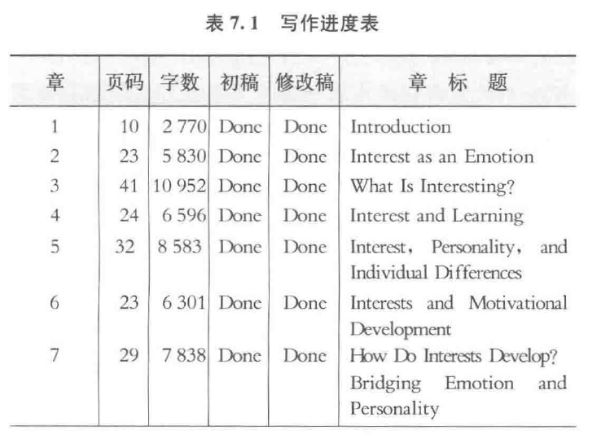

### 三、怎样找到一位出版商

对出版商而言，每一本书都是一场赌博。

- 写完几章之后，你就应该和图书编辑取得初次联系。
- 如果你跟出版社签了约，那么你的书就“正式而世俗”地存在了。如果你违约，就会显得很不专业，编辑会不高兴；如果你拿了预付款，你还会欠编辑一笔钱。所以,在你确信你与自己的约定不会被违背以前，不要随便签署一份出版合同。
- 在考虑出版商的时候,挑选那些长期以来一直活跃在你研究领域的出版商。

（1）合同会约定一个交稿日 （2）作者和出版商都会十分在意版税问题 （3）出版商往往会拿预付款来诱惑作者，如果你不需要预付款，你可以拒绝它。 （4）合同会列明谁负责申请授权（允许影印来自他人的资料）、画图表和完成索引。通常作者会负责完成上述工作，不过教科书的出版商常常宁愿自己来完成。 （5）合同会约定将来如何处理图书的修订。 （6）合同会说明谁拥有此书的版权。对于学术著作,出版商一般拥有该书的版权。出版商还必须说明如果书籍脱销了怎么办。合同通常会约定，作者有权在著作脱销6个月以上的情况下要求出版商再次印刷。如果出版商拒绝，那么作者有权收回该书的出版权。你一定要争取在著作脱销的情况下获得你应有的权利，这样你能够有机会对著作进行修改，然后另外找一家出版商重新出版。 （7）出版商有可能会要求增加一条“优先拒绝权”条款，意思是即便该出版商决定不出版你的下一本书,他们也有权优先获得出版意向书。

### 四、处理一些细节问题

出版商会给你寄一份详细的作者调查表，询问一些关于你和你的作品的问题。这份资料将来会用于图书归类、营销和推广活动，所以你需要花点精力来好好考虑。也许他们还会让你推荐几位艺术家或学者来设计推荐广告。

现在你的专著进入了待出版环节，你需要准备好迎接大量的编辑和校对工作一你想象中的成堆的喜悦化成了成堆的工作。你可以付一笔钱让别人帮你校对清样。你自己当然也要校对，但是你需要另一位读者用全新的视角来阅读。

如果你需要准备索引，你应该在收到清样的时候弄好它。

### 五、小结

写书没有什么神秘之处，只是机械地执行你的写作计划。

如果你有话想说，请写一本书。如果你有很多话想说，请写两本书。

## 第八章 还有好东西要写

本书介绍了一个实用的体系，目的是帮助你成为一位高产的学术写作者。第二章反驳了妨碍人们写得更多的一些借口，并介绍了整个体系的核心：按照写作计划按时写作。为了帮助你执行写作计划，第三章和第四章描述了如何设定好的目标和优先项，如何监控写作和如何组建“失写互助组”。第五章告诉你如何写得更好，第六、第七章提供了一些关于期刊论文写作和专著写作的有用的建议。令人感到讽刺的是，这本介绍如何写得更多的书本身篇幅却很短，但是我要说的已经都在这里了。这个体系其实很简单。

### 一、计划之乐

执行写作计划的过程是充满乐趣的。

- 你每周可以写更多页的文章，这样你就能完成更多的期刊论文、更多的课题报告、更多的章节和更多的专著。
- 按计划写作，你就能将“找时间写作”的不确定性和痛苦转化为对“什么时候能完成”的期待。
  - 项目都能够在截止期限前完成。
  - 你在开学第一周花在写作 上的时间和暑假里一样长：你的写作计划让你的写作成果呈现出令人赏心悦目的正态分布。
- 写作会变得寻常、固定和有规律，而不是沉重、无常和被迫。

令人意想不到的快乐：手工业者的骄傲。

- 外在的对写作的奖励很有限，而且难以预料一一往往是在一堆拒信中能够找出一份用稿通知。
- 内在的奖赏对于突击写作者来说更是稀有。
  - 突击写作者总是带着罪恶和紧张的情绪，从来不觉得写作的过程是有意义的。正因为长时间地持续恶性循环，写作对于突击写作者而言总是和精疲力竭的阴霾相伴，这更加剧了他们对写作的厌恶。
- 当你执行写作计划的时候，你掌控了你的自我强化计划(Skinner,1987)。你知道什么时候你将因为实现了目标而得到奖赏。

我的目标是每个工作日早上写作。有时候我写了很多；有时候却收获甚少，疲惫不堪。但是即使是在那些糟糕的日子里，我还是为我能坐下来写作感到高兴：我很自豪地在我的SPSS表格里打上“1”，然后我给自己一个小小的奖励（比如来一杯上等的咖啡）。我从不想写作——想出门去吃个面包圈的冲动有时候很强烈，但是不管怎样我写了。

**在坚持写了这么久以后，正是每天的小小胜利，而不是最终发表的成就感，激励着我坚持写作。**

### 二、少点空想，多些实干

- 你不需要特殊的天赋、基因或是动力来帮助你写得更多。
- 你也不需要“想写"才写——人们通常很难喜欢这项毫无乐趣又没有截止期限的工作——所以不必等到你喜欢上写作才写作。
- 高效的写作有赖于习惯的力量，而习惯养成的关键在于重复。
- 制订一个写作计划，然后坐下来写作。最初的几个星期，你或许会怨天尤人，还会恨得牙痒痒，但至少你是在计划写作的时间里诅咒，而非无所事事的时候。熬过了几周之后，你就会对写作安排习以为常，而你再也不用承受除此之外的时间里必须写作的压力了。一旦你的写作计划僵化成一种牢固的习惯，你就会对“想要写东西”的论述感到不可思议。习惯的力量会促使你坐下来写作。

令人感到讽刺的是，写得更多并不会让你喜欢上写作或者更想写作。

- 写作很难，永远都很难；写作令人头疼，永远都令人头疼。
- 大多数日子里，我都不想坐在那张硬邦邦的椅子上，打开电脑，继续一篇写了一半的论文。不过，上课也令人沮丧；奋战在冗长的会议中就更别提了。
- 那么，人们是怎么对待这些任务的呢？他们只是“出现"而已。
- 做一个写作计划，然后按时“出现”。少些空想，多点实干。

威廉•津泽(WilliamZinsser,2001：285)说：“想好你要做什么，然后做好决定，然后开始做。”

### 三、写作不是比赛

你想写多少，就写多少。

- 虽然本书介绍了如何写得更多的方法，但是千万不要觉得写得越多便越好。
- 如果你想写得更多，那么写作计划能够帮助你。
- 你每周会花更多的时间写作，也会更高效。逐渐地，你就会把那些堆积如山的数据清理干净，你写作的时候也会更为得心应手。
- 如果你不想写得更多，写作计划能够帮助你消除写作带来的罪恶感和不确定性。
- 你就不用总是牺牲周末的时间来进行无谓的突击写作了。如果你一生中只打算写很少的作品，那你的写作时间可以用来思考。用这些时间来阅读和思考你的职业发展。

文章发表得更多并不意味着你就是一位更为成功的人、心理学家或科学家。

- 心理学界许多高产的作者不停地重复着同一个观点：从论文到评论文章，从评论文章到专著的部分章节，从部分章节再到报刊文章和专业指南的某个章节。
- 高产的写作者会有更多的公开作品，但并不一定就比别人有更多好的观点。
- 写作不是比赛。不要仅仅为了发表而发表。
- 不要计算你发表了多少文章，出版了多少专著。

### 四、享受生活

一份写作时间表能够平衡你的生活，不是伪科学里所谓内心无欲无求之后获得的奇妙平衡感，而是将工作与娱乐区分开来的平衡。

突击写作者傻傻地寻找着整块的时间，但是他们找到的是晚上和周末。于是，他们牺牲了正常的生活。

- 学术写作真的比与家人共处、爱抚小狗、品尝上好的咖啡更为重要吗？你应该像保护你的写作时间一样保护你的正常生活。
- 晚上和周末的时间应该用来与家人朋友团聚，制作独木舟参加阿尔瓦•阿尔托(AlvarAalto)老式家具拍卖，尽管你未必需要它们，看最新的电视剧，粉刷百叶窗或者教你的猫怎么上厕所。
- 随便你如何打发你的业余时间，就是别写东西——你在工作日有时间干这个。

### 五、小结

这本书告一段落了。谢谢你的阅读。

- 对我来说，是时候写点别的了。
- 对你来说，也是时候写点别的了。

威廉•萨拉扬(WilliamSaroyan,1952：2)这样写道：“每当我想着还有好东西要写的时候，我都欣喜无比，因为好东西永远写不完，而我知道我会成就其中的一部分。”